# Gentle introduction to social networks in R

[figure not shown]

### Prof. Jose Manuel MAGALLANES.

- Professor at Pontificia Universidad Católica del Peru
- Senior Data Scientist at eScience Institute, University of Washington

## CONTENTS:

### 1. Network Creation from dataframes

These data frames have been previously prepared, based on the data from [50 influential people in Seattle tech to follow on Twitter](https://www.builtinseattle.com/2018/08/06/50-seattle-tech-twitter-accounts-to-follow). The file can be seen [here](https://docs.google.com/spreadsheets/d/e/2PACX-1vTpWvtfphnO9eRYwmEyxVAxxo1KEsdpK6sK6q5uhJn5x2QtB-eGiso8ibpF16NaHAers4wDIHkvBo64/pubhtml), and includes 3 sheets:

- Network as two columns representing edges.
- Network as adjacency matrix.
- Attributes of the Network nodes.

```r
rm(list = ls())
##
fileLink='https://github.com/eScience-UW/gentleIntro_networks/raw/main/data/seattleTop.xlsx'

edges=rio::import(fileLink, which = 'edges')
adjacency=rio::import(fileLink, which = 'adjacency')
attributes=rio::import(fileLink,which ="attributes")
```

Use the previous dataframes to create the network:

- From the edges:

```r
library(igraph) # package needed

EliteNet=graph_from_data_frame(edges, directed = F)

summary(EliteNet)
```

```
IGRAPH d0b232c UN-- 46 393 --
+ attr: name (v/c)
```

- From adjacency matrix:

```r
#prepare matrix
row.names(adjacency)=adjacency[,1] #first column for index
adjacency=adjacency[,-1] # deleting the first column
adjacencyMatrix=as.matrix(adjacency)

# the making...
EliteNet=graph_from_adjacency_matrix(adjacencyMatrix,mode="undirected")


summary(EliteNet)
```

```
IGRAPH 5fd65de UN-- 46 393 --
+ attr: name (v/c)
```

See inside:

```r
V(EliteNet)
```

```
+ 46/46 vertices, named, from 5fd65de:
 [1] rachelerman     mattmcilwain    DaveParkerSEA   toddbishop      ashannstew
 [6] LeslieFeinzaig  akipman         matt_oppy       gilbert         juliesandler
[11] BradSmi         crashdev        ShaunaCausey    john_gabbert    moniguzman
[16] mattmday        Rich_Barton     daryn           lovelletters    etzioni
[21] MissDestructo   heatherredman   danshapiro      medinism        KieranSnyder
[26] hadip           RajSinghSeattle funcOfJoe       kirbywinfield   stevesi
[31] Ryanintheus     sonalpmane      SoGulley        2morrowknight   jinman
[36] tarah           Jenerationy     lanctot         Kristen_Hammy   nhuntwalker
[41] eugenio_pace    JenMsft         PeterHamilton   sarahstood      mcolacurcio
[46] marybethlambert
```

```r
E(EliteNet)
```

```
+ 393/393 edges from 5fd65de (vertex names):
 [1] rachelerman--mattmcilwain    rachelerman--DaveParkerSEA   rachelerman--toddbishop
 [4] rachelerman--ashannstew      rachelerman--LeslieFeinzaig  rachelerman--akipman
 [7] rachelerman--matt_oppy       rachelerman--gilbert         rachelerman--juliesandler
[10] rachelerman--BradSmi         rachelerman--crashdev        rachelerman--ShaunaCausey
[13] rachelerman--john_gabbert    rachelerman--moniguzman      rachelerman--mattmday
[16] rachelerman--Rich_Barton     rachelerman--daryn           rachelerman--lovelletters
[19] rachelerman--etzioni         rachelerman--MissDestructo   rachelerman--heatherredman
[22] rachelerman--danshapiro      rachelerman--medinism        rachelerman--KieranSnyder
[25] rachelerman--hadip           rachelerman--RajSinghSeattle rachelerman--Ryanintheus
[28] rachelerman--sonalpmane      rachelerman--Jenerationy     rachelerman--marybethlambert
+ ... omitted several edges
```

### 2. Adding Attributes

Attributes are added using **vectors**:

```r
# edges
E(EliteNet)$weight=1
# EliteNet=set_edge_attr(EliteNet,"weight", value = 1)

#nodes
V(EliteNet)$male=attributes$male
V(EliteNet)$followers=attributes$followers
# EliteNet=set_vertex_attr(EliteNet, "followers", value=attributes$followers)
```

```r
##
# E(EliteNet)$weight
# edge_attr_names(EliteNet)
# V(EliteNet)$followers
# vertex_attr_names(EliteNet)
summary(EliteNet)
```

```
IGRAPH 5fd65de UNW- 46 393 --
+ attr: name (v/c), male (v/n), followers (v/n), weight (e/n)
```

You can use attributes to color nodes:

```r
library(ggraph)

base=ggraph(graph = EliteNet)
```

```
Using "stress" as default layout
```

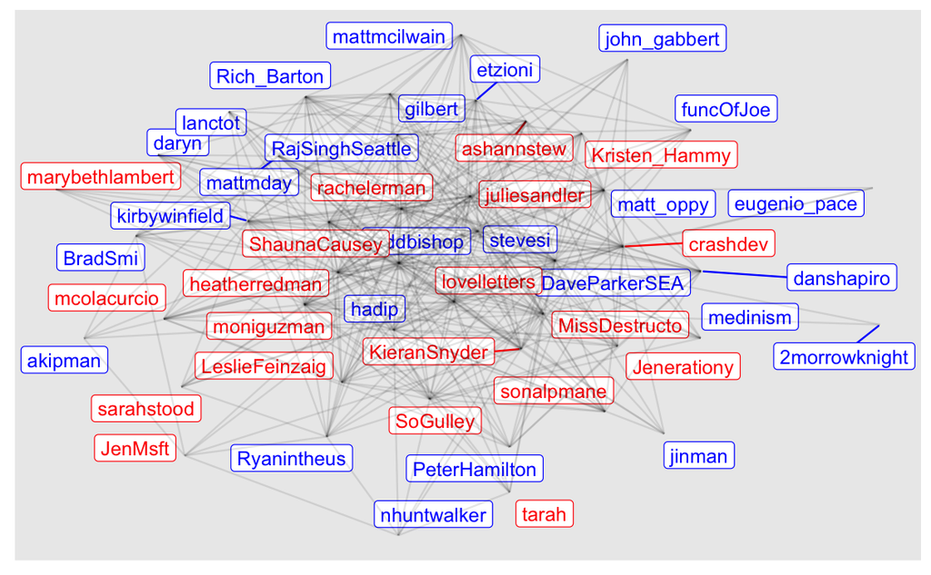

```r
base + geom_node_label(aes(label = name,
                           color=as.factor(male)),
                       repel = TRUE,show.legend = F) +
       geom_edge_link(alpha=0.1) +
       scale_color_manual(values = c('red','blue'))
```

```r
NA
```

## 3. Exploring the Network

- Connectedness: A network is “connected” if there exists a *path* between any pair of nodes (undirected networks).

```r
is_connected(EliteNet)
```

```
[1] TRUE
```

- Density: from 0 to 1, where 1 makes it a ‘complete’ network: there is a link between every pair of nodes.

```r
graph.density(EliteNet)
```

```
[1] 0.3797101
```

- Diameter: When two vertices are connected, one can reach the other using multiple egdes. The geodesic is the shorthest path between two connected vertices. Then, the diameter, is the maximum geodesic in a network.

```r
diameter(EliteNet)
```

```
[1] 3
```

- Assortativity: it is a measure to see if nodes are connecting to other nodes similar to themselves. Closer to 1 means higher assortativity, closer to -1 diassortativity; while 0 is no assortativity.
  - Degree assortativity: tendency for highly connected nodes to be connected among themselves.

```r
assortativity_degree(EliteNet,directed=F)
```

```
[1] -0.2541114
```

```
- Categorical assortativity: tendency for nodes with other nodes sharing the same category.
```

```r
assortativity_nominal(EliteNet,as.factor(V(EliteNet)$male),directed = F)
```

```
[1] 0.04310211
```

```
- Assortativity (numerical):
```

```r
assortativity(EliteNet,V(EliteNet)$followers,directed = T)
```

```
[1] -0.04515662
```

## 4. Exploration of Network nodes

- The eigenvector of a vertex will tell you how well connected is a vertex; that is, vertices with the highest values are considered the most influential as they are connected to vertices that are also well connected.
- The closeness of a vertex will tell you how close is a vertex to every other vertex. A vertex with high closeness can share information faster than the rest.
- The betweeness of a vertex will tell you how critical is a vertex to connect vertex that are not connected directly.

```r
eigen=eigen_centrality (EliteNet,scale=F)$vector

close=closeness(EliteNet,normalized=T)

betw=betweenness(EliteNet,normalized=T)

DFCentrality=as.data.frame(cbind(eigen,close,betw),stringsAsFactors = F)
names(DFCentrality)=c('Eigenvector','Closeness','Betweenness')

DFCentrality$person=row.names(DFCentrality)
row.names(DFCentrality)=NULL
```

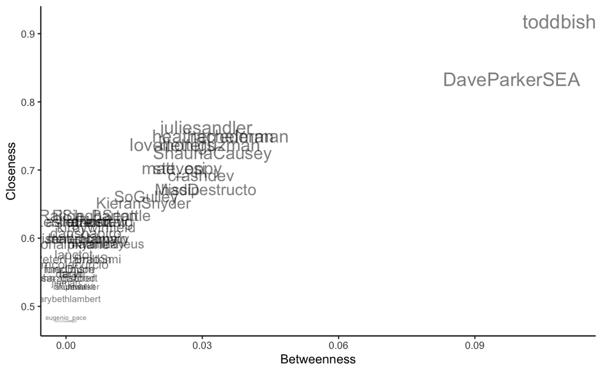

```r
library(ggplot2)
ggplot(DFCentrality, aes(x=Betweenness, y=Closeness)) +
    theme_classic() +
    geom_text(aes(label=person,size=Eigenvector),show.legend = F,alpha=0.5)
```

The previous results tells us that two people are salient:

```r
HubNodes=dplyr::top_n(DFCentrality,2,Eigenvector)$person
HubNodes
```

```
[1] "DaveParkerSEA" "toddbishop"
```

Let’s highlight those guys:

```r
NodeCount=length(V(EliteNet))

V(EliteNet)$label=''

for (index in seq(1:NodeCount)){
    currentName=V(EliteNet)$name[index]
    if (currentName%in%HubNodes){
            V(EliteNet)$label[index]=currentName
    }
}
```

```r
library(ggraph)

base=ggraph(graph = EliteNet)
```

```
Using "stress" as default layout
```

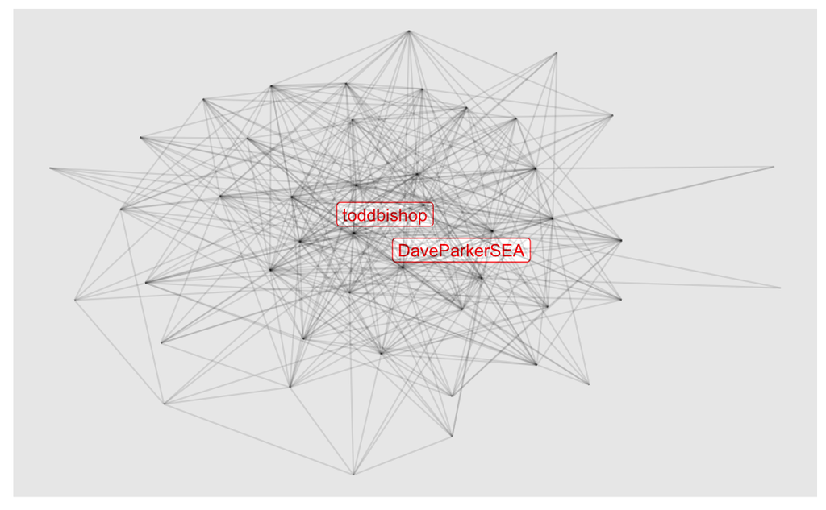

```r
base  + geom_node_label(aes(label = label),
                        repel = TRUE,
                        show.legend = F,
                        color='red') +
         geom_edge_link(alpha=0.1)
```